# Lab8-Block Treaments

Katherine Filpo

2/28/2020

```r
knitr::opts_chunk$set(echo = TRUE)
library(ggplot2)
SAPLINGS <- read.csv("~/Documents/BioStats/lab8/SAPLINGS.csv")
```

## Question 1: Is length explained by water?

H<sub>0</sub> There is no relationship between water treatment and length of plant.

H<sub>A</sub> The water treament will affect the length of plant, in the manor that the more water, the longer the plant.

```r
model_1<-aov(SAPLINGS$FINALHT ~factor(SAPLINGS$WATER_TREAT))
summary(model_1)
```

```
##                              Df Sum Sq Mean Sq F value Pr(>F)
## factor(SAPLINGS$WATER_TREAT)  3  12.89   4.298   1.972  0.136
## Residuals                    36  78.46   2.179
```

#### Plot of the water treament and sapling length

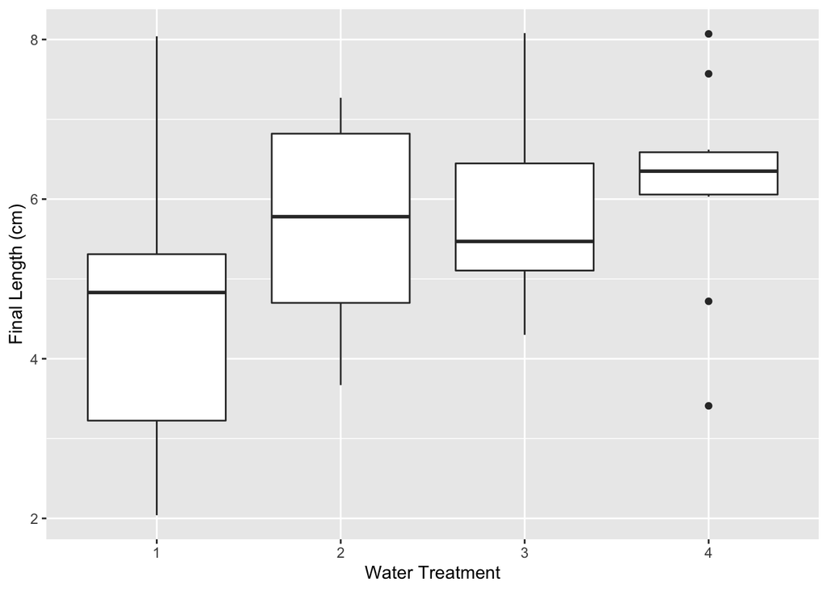

**Figure 1.** The water treatment for seems to have a weak effect on the final length of the plats but wothout taking into effect the initial length, it is not possible to conclude without a doubt that it is only due to the water treatment, so we cannot accept or reject the hypothesis. (*F*<sub>(3,36)</sub> = 1.9721) (lower the f the higher the p)

## Question 2: Testing the initial height

H<sub>0</sub> The initial height of the plant has no relationship on the final length of the plant.

H<sub>A</sub> THe initial height of the plant has an effect on the final length of the plant.

```r
model_2<-aov((SAPLINGS$FINALHT-SAPLINGS$INITHT)~factor(SAPLINGS$WATER_TREAT))
summary(model_2)
```

```
##                              Df Sum Sq Mean Sq F value   Pr(>F)
## factor(SAPLINGS$WATER_TREAT)  3 1.0859  0.3620   17.35 3.89e-07 ***
## Residuals                    36 0.7509  0.0209
## ---
## Signif. codes:  0 '***' 0.001 '**' 0.01 '*' 0.05 '.' 0.1 ' ' 1
```

## Question 3: Two way Anova

H<sub>0</sub> The initial height has no effect on the final height of the plants even when taking into account the wter treatment.

H<sub>A</sub> The iniital height and the water treatment both have an effect on the final height of the plants.

```r
model_3<-aov(SAPLINGS$FINALHT~ SAPLINGS$INITHT + factor(SAPLINGS$WATER_TREAT))
summary(model_3)
```

```
##                              Df Sum Sq Mean Sq  F value   Pr(>F)
## SAPLINGS$INITHT               1  90.11   90.11 16637.38  < 2e-16 ***
## factor(SAPLINGS$WATER_TREAT)  3   1.05    0.35    64.74 2.32e-14 ***
## Residuals                    35   0.19    0.01
## ---
## Signif. codes:  0 '***' 0.001 '**' 0.01 '*' 0.05 '.' 0.1 ' ' 1
```

#### Plot of the effect of water treament on height when taking into account the initial height (two way anova)

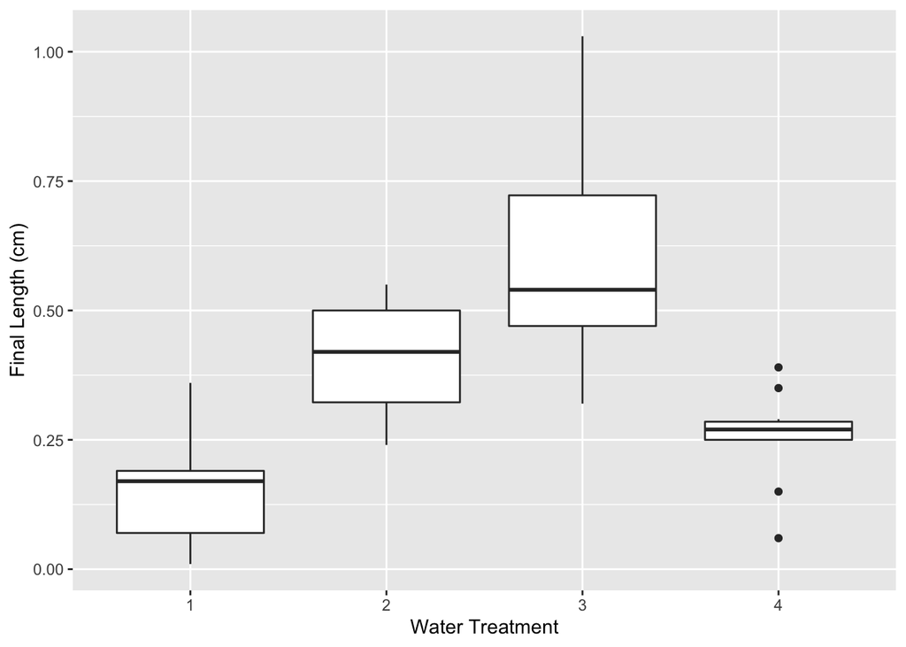

## Conclusion

Taking into account the initial legnth and the water treament, there is an effect of the water treatment so the H<sub>A</sub> is supported.